# Series_de_Tiempo_Segundo_Parcial_v2

Sergibar

2023-06-01

# Universidad Nacional Autónoma de México

# Posgrado en Ingeniería de Sistemas

# Series de tiempo Dr. Wulfrano Gomez Gallardo

# Segundo Parcial: Aplicaicón de métodos ARIMA / SARIMA para pronóstico de series de tiempo (3 casos aplicativos)

# Serie de tiempo 1 SIN tendencia y SIN estacionalidad: Historico anual Accidentes terrestres en México

Primero importamos la data de Accidentes terrestres en MEX Data obtenida de la página oficial del INEGI: https://www.inegi.org.mx/temas/accidentes/

```r
library("readxl")
Accidentes_transito_MEX <-read_excel("Accidentes_transito_full_.xlsx")
```

Revisamos que la data de Accidentes_transitos MEX se haya importado correctamente

```r
Accidentes_transito_MEX
```

```
## # A tibble: 22 × 2
##    Date                   Num
##    <dttm>               <dbl>
##  1 2000-01-12 00:00:00 331938
##  2 2001-01-12 00:00:00 364869
##  3 2002-01-12 00:00:00 399002
##  4 2003-01-12 00:00:00 403940
##  5 2004-01-12 00:00:00 424940
##  6 2005-01-12 00:00:00 434940
##  7 2006-01-12 00:00:00 444940
##  8 2007-01-12 00:00:00 454940
##  9 2008-01-12 00:00:00 436435
## 10 2009-01-12 00:00:00 418467
## # … with 12 more rows
```

```r
summary(Accidentes_transito_MEX)
```

```
##       Date                          Num
##  Min.   :2000-01-12 00:00:00   Min.   :315068
##  1st Qu.:2005-04-13 06:00:00   1st Qu.:358355
##  Median :2010-07-13 12:00:00   Median :373092
##  Mean   :2010-07-13 12:00:00   Mean   :385115
##  3rd Qu.:2015-10-12 18:00:00   3rd Qu.:416417
##  Max.   :2021-01-12 00:00:00   Max.   :454940
```

```r
typeof(Accidentes_transito_MEX)
```

```
## [1] "list"
```

```r
dim(Accidentes_transito_MEX)
```

```
## [1] 22  2
```

#### Convertimos los data importada a Serie de tiempo

```r
Accidentes_transito_MEX_ts<- ts(Accidentes_transito_MEX$Num, frequency = 1)
head(Accidentes_transito_MEX_ts)
```

```
## [1] 331938 364869 399002 403940 424940 434940
```

```r
typeof(Accidentes_transito_MEX_ts)
```

```
## [1] "double"
```

Graficamos la serie del tiempo

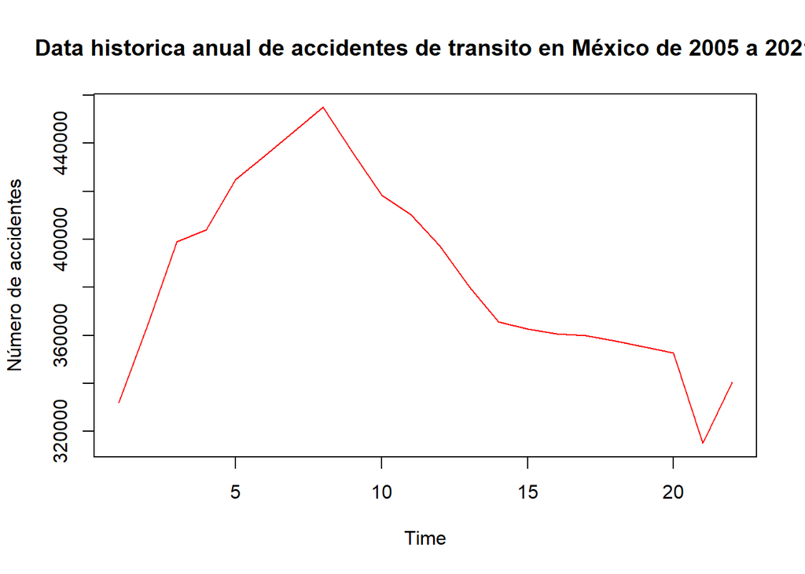

```r
plot(Accidentes_transito_MEX_ts, col = "red", main = "Data historica anual de accidentes de transito en México de 2005 a 2021", ylab="Número de accidentes")
```

### Analicemos los valores de la variable y

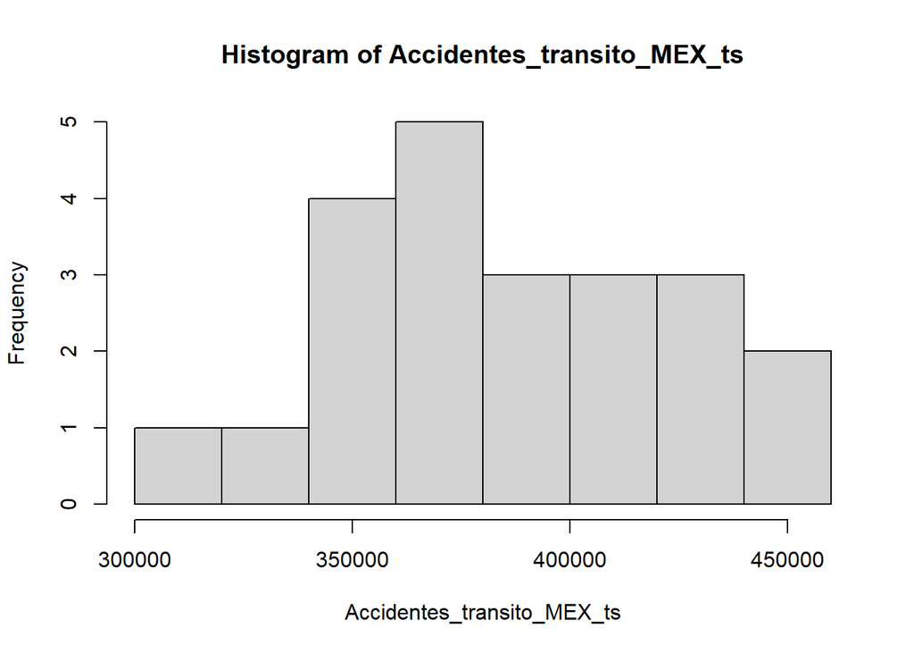

```r
hist(Accidentes_transito_MEX_ts)
```

```r
summary(Accidentes_transito_MEX_ts)
```

```
##    Min. 1st Qu.  Median    Mean 3rd Qu.    Max.
##  315068  358355  373092  385115  416417  454940
```

```r
library(e1071)

# Calculate skewness
skewness_value <- skewness(Accidentes_transito_MEX_ts)

# Calculate kurtosis
kurtosis_value <- kurtosis(Accidentes_transito_MEX_ts)

# Print the results
print(paste("Skewness:", skewness_value))
```

```
## [1] "Skewness: 0.162903825127994"
```

```r
print(paste("Kurtosis:", kurtosis_value))
```

```
## [1] "Kurtosis: -1.22513972450163"
```

#### Separamos el en data sets train y test

Se tienen 22 datos, por lo que el train será de 19 datos, para que el test sea de 3 datos o 3 años

```r
# Split the data into training and testing sets


# Subset the data to keep rows from the beginning until train_end and all columns
Accidentes_transito_MEX_ts_train <- Accidentes_transito_MEX_ts[1:19]
head(Accidentes_transito_MEX_ts_train)
```

```
## [1] 331938 364869 399002 403940 424940 434940
```

```r
tail(Accidentes_transito_MEX_ts_train)
```

```
## [1] 365772 362574 360573 360051 357789 355281
```

```r
# Subset the data to keep rows from the beginning until train_end and all columns


# Subset the data to keep rows from the beginning until train_end and all columns
Accidentes_transito_MEX_ts_test <- Accidentes_transito_MEX_ts[20:22]
head(Accidentes_transito_MEX_ts_test)
```

```
## [1] 352729 315068 340415
```

```r
tail(Accidentes_transito_MEX_ts_test)
```

```
## [1] 352729 315068 340415
```

## Modelo SARIMA para Serie 1 (Accidentes terrestres en México)

#### Determinación de ACF & PACF para el caso de la serie 1 (Accidentes transitos Mex) sin diferneciar

```r
#install.packages("forecast")
library(forecast)
```

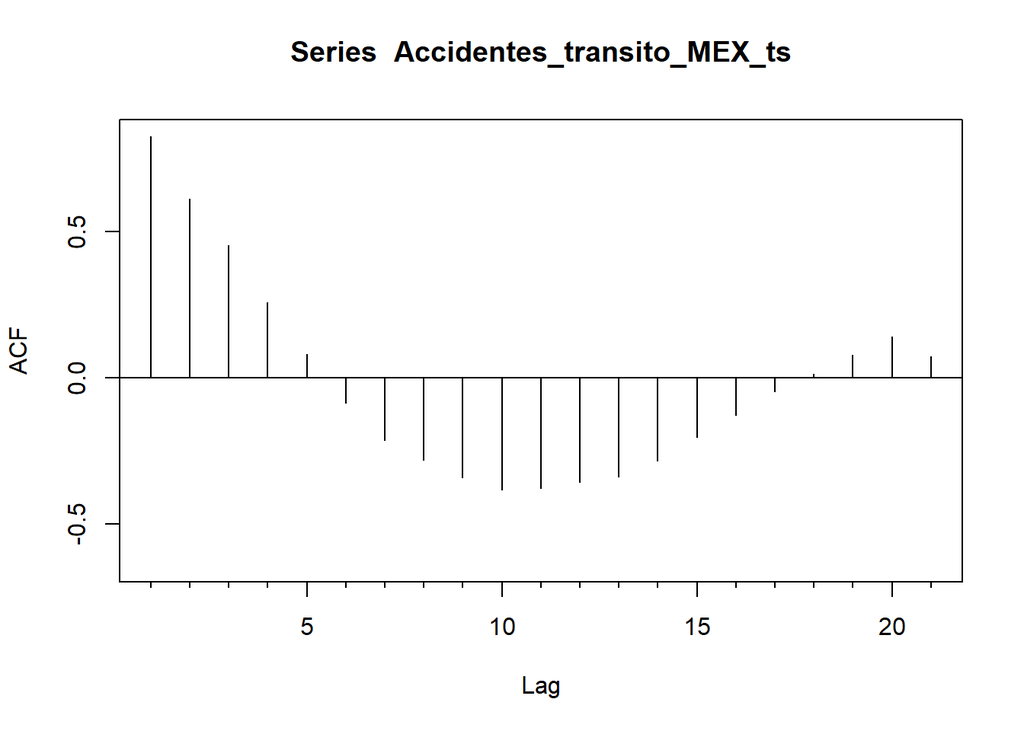

```r
#par(mfrow=c(2,1))

acf_Accidentes_transito_MEX_ts_sin_diferenciar <- Acf(Accidentes_transito_MEX_ts, lag.max = 100, ci.type = "ma")
```

```r
head(acf_Accidentes_transito_MEX_ts_sin_diferenciar)
```

```
##
## Autocorrelations of series 'Accidentes_transito_MEX_ts', by lag
##
##      1      2      3      4      5      6
##  0.826  0.613  0.455  0.258  0.082 -0.085
```

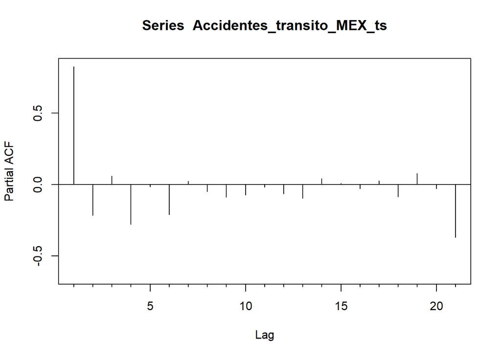

```r
pacf_Accidentes_transito_MEX_ts_sin_diferenciar <- Pacf(Accidentes_transito_MEX_ts, lag.max = 100, ci.type = "ma")
```

```r
head(pacf_Accidentes_transito_MEX_ts_sin_diferenciar)
```

```
##
## Partial autocorrelations of series 'Accidentes_transito_MEX_ts', by lag
##
##      1      2      3      4      5      6
##  0.826 -0.218  0.060 -0.279 -0.017 -0.211
```

La función ACF de la serie, nos refleja la forma ‘original’ de la serie donde los primeros años hay una tendencia creciente y posteriormente una decreciente. El hecho de que la serie muestra varios valores significativos para la gráfica de ACF sugiere que No es una serie estacionaria, para estar 100% seguros heremos un test de Dickey-Fuller

#### Se lleva a cabo el tet de Dickey-Fulley (Ho: Serie no estacionaria) de la serie 1 (Accidentes transitos Mex)

```r
# Install and load the "urca" package
#install.packages("urca")
library(urca)

# Perform ADF test for stationarity
acf_test_Accidentes_transito_MEX_ts_sin_diferenciar <- ur.df(Accidentes_transito_MEX_ts)

# Print the ADF test results
summary(acf_test_Accidentes_transito_MEX_ts_sin_diferenciar)
```

```
##
## ###############################################
## # Augmented Dickey-Fuller Test Unit Root Test #
## ###############################################
##
## Test regression none
##
##
## Call:
## lm(formula = z.diff ~ z.lag.1 - 1 + z.diff.lag)
##
## Residuals:
##    Min     1Q Median     3Q    Max
## -35636  -8245   -545   5636  38459
##
## Coefficients:
##             Estimate Std. Error t value Pr(>|t|)
## z.lag.1    -0.003430   0.009306  -0.369    0.717
## z.diff.lag  0.319471   0.212886   1.501    0.151
##
## Residual standard error: 16300 on 18 degrees of freedom
## Multiple R-squared:  0.1181, Adjusted R-squared:  0.02007
## F-statistic: 1.205 on 2 and 18 DF,  p-value: 0.3228
##
##
## Value of test-statistic is: -0.3686
##
## Critical values for test statistics:
##       1pct  5pct 10pct
## tau1 -2.66 -1.95  -1.6
```

Se observa como el valor p de la prueba DF de estacionariedad p> 0.05 por lo tanto NO se rechaza Ho que indica que la serie no es estacionaria.

Para intentar “hacer estacionaria la serie vamos a tomar la primer diferencia de Yt con Yt-1”

#### Vamos a diferenciar la serie 1 (Accidentes transitos Mex) ‘para hacerlo estacionaria’

```r
# Calculate the difference between consecutive elements
Accidentes_transito_MEX_ts_diferencia1 <- diff(Accidentes_transito_MEX_ts, differences = 1)

# Print the results
print(Accidentes_transito_MEX_ts_diferencia1)
```

```
## Time Series:
## Start = 2
## End = 22
## Frequency = 1
##  [1]  32931  34133   4938  21000  10000  10000  10000 -18505 -17968  -8200
## [11] -13082 -16774 -14639  -3198  -2001   -522  -2262  -2508  -2552 -37661
## [21]  25347
```

#### ACF & PACF para los la serie 1 (Accidentes transitos Mex) diferencia1 ‘estacionariazada’

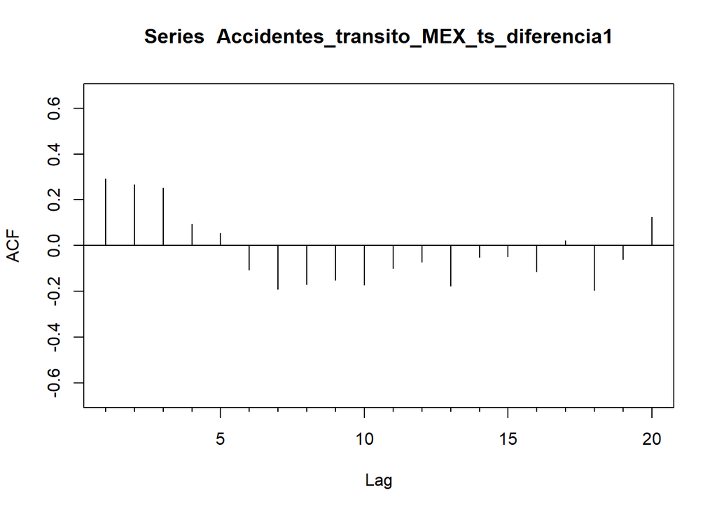

```r
library(forecast)

#par(mfrow=c(2,1))

acf_test_Accidentes_transito_MEX_ts_diferencia1 <- Acf(Accidentes_transito_MEX_ts_diferencia1, lag.max = 100, ci.type = "ma")
```

```r
head(acf_test_Accidentes_transito_MEX_ts_diferencia1)
```

```
##
## Autocorrelations of series 'Accidentes_transito_MEX_ts_diferencia1', by lag
##
##      1      2      3      4      5      6
##  0.292  0.267  0.253  0.094  0.053 -0.107
```

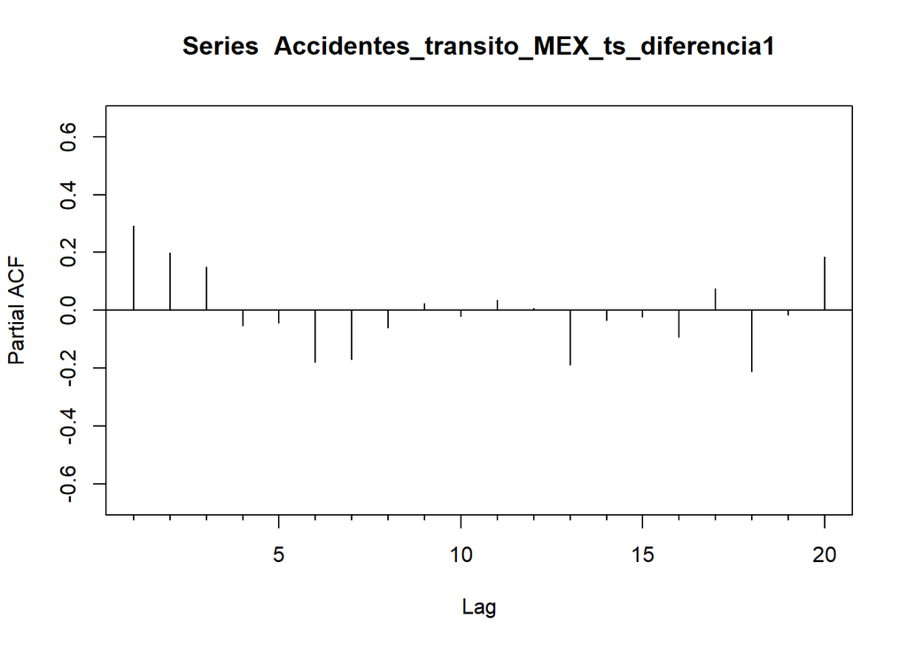

```r
pacf_test_Accidentes_transito_MEX_ts_diferencia1 <- Pacf(Accidentes_transito_MEX_ts_diferencia1, lag.max = 100, ci.type = "ma")
```

```r
head(pacf_test_Accidentes_transito_MEX_ts_diferencia1)
```

```
##
## Partial autocorrelations of series 'Accidentes_transito_MEX_ts_diferencia1', by lag
##
##      1      2      3      4      5      6
##  0.292  0.198  0.151 -0.053 -0.044 -0.180
```

Todo indica que la primer diferenciación de la seria ayudó a hacerla estacionaria. Se hace nuevamente una prueba de Dickey-Fulley para verificar estacionariedad

#### Se lleva a cabo el tet de Dickey-Fulley (Ho: Serie no estacionaria) a la serie 1 <diferenciar 1>

```r
# Install and load the "urca" package
#install.packages("urca")
library(urca)

# Perform ADF test for stationarity
acf_test_Accidentes_transito_MEX_ts_diferencia1 <- ur.df(Accidentes_transito_MEX_ts_diferencia1)

# Print the ADF test results
summary(acf_test_Accidentes_transito_MEX_ts_diferencia1)
```

```
##
## ###############################################
## # Augmented Dickey-Fuller Test Unit Root Test #
## ###############################################
##
## Test regression none
##
##
## Call:
## lm(formula = z.diff ~ z.lag.1 - 1 + z.diff.lag)
##
## Residuals:
##    Min     1Q Median     3Q    Max
## -36801  -8414  -1757   3586  22251
##
## Coefficients:
##            Estimate Std. Error t value Pr(>|t|)
## z.lag.1     -0.6551     0.2373  -2.761   0.0134 *
## z.diff.lag  -0.4581     0.2752  -1.665   0.1143
## ---
## Signif. codes:  0 '***' 0.001 '**' 0.01 '*' 0.05 '.' 0.1 ' ' 1
##
## Residual standard error: 14470 on 17 degrees of freedom
## Multiple R-squared:  0.527,  Adjusted R-squared:  0.4714
## F-statistic: 9.471 on 2 and 17 DF,  p-value: 0.001723
##
##
## Value of test-statistic is: -2.7611
##
## Critical values for test statistics:
##       1pct  5pct 10pct
## tau1 -2.66 -1.95  -1.6
```

Con un valor de p<0.05 se comprueba que la serie 1 (Accidentes transitos Mex) con 1 diferencia ya es estacionaria.

Con base en las gráficas de ACF y PACF (y teniendo en cuenta el principio de parcimonia) se decide probar un modleo ARIMA (1,1,1)

#### Ajustae y predicicon de para serie 1 (Accidentes transitos Mex) con modelo ARIMA

```r
#install.packages("astsa")
library(astsa)
# Fit the SARIMA model
ARIMA_1_1_1_Accidentes_transito_Mex <- astsa::sarima(Accidentes_transito_MEX_ts_train , p=1, d=1, q=1)
```

[figure not shown]

```r
# Print the model summary
summary(ARIMA_1_1_1_Accidentes_transito_Mex)
```

```
##                    Length Class  Mode
## fit                14     Arima  list
## degrees_of_freedom  1     -none- numeric
## ttable             12     -none- numeric
## AIC                 1     -none- numeric
## AICc                1     -none- numeric
## BIC                 1     -none- numeric
```

En general se observa para el modelo ARIMA_1_1_1_Accodentes_transito_Mex:

Los errores estandarizados tienen un compartiempo aprorximadamente normal con media cero Los errores estandarizados no tiene una correlación signifcativa

#### Calculo de predicción para serie 1 (Accidentes transitos Mex) con modelo ARIMA

```r
# Get the predictors


pred_ARIMA_1_1_1_Accidentes_transito_Mex <- sarima.for(Accidentes_transito_MEX_ts_train, n.ahead=3,1,1,1)
```

[figure not shown]

```r
pred_ARIMA_1_1_1_Accidentes_transito_Mex
```

```
## $pred
## Time Series:
## Start = 20
## End = 22
## Frequency = 1
## [1] 354512.8 354780.4 355937.7
##
## $se
## Time Series:
## Start = 20
## End = 22
## Frequency = 1
## [1] 10822.29 20763.42 31467.28
```

```r
pred_ARIMA_1_1_1_Accidentes_transito_Mex$pred
```

```
## Time Series:
## Start = 20
## End = 22
## Frequency = 1
## [1] 354512.8 354780.4 355937.7
```

#### Calculo de errores del modelo ARIMA para serie 1 (Accidentes transitos Mex)

```r
accuracy(Accidentes_transito_MEX_ts_test ,pred_ARIMA_1_1_1_Accidentes_transito_Mex$pred )
```

```
##                ME    RMSE      MAE      MPE     MAPE       ACF1 Theil's U
## Test set 19006.31 24638.8 19006.31 5.352588 5.352588 -0.5813522  35.91902
```

El MAPE del modelo ARIMA 1,1,1 para la serie 1 (Accidentes transitos Mex) es de ~5.3%

#### Ajustae y predicicon con modelo SARIMA para serie 1 (Accidentes transitos Mex)

```r
#install.packages("astsa")
library(astsa)

# Fit the SARIMA model
SARIMA_Accidentes_transito_Mex <- Arima(Accidentes_transito_MEX_ts_train, order = c(1, 1, 1), seasonal = list(order = c(1, 0, 0), period = 1))

# Print the model summary
summary(SARIMA_Accidentes_transito_Mex)
```

```
## Series: Accidentes_transito_MEX_ts_train
## ARIMA(1,1,1)
##
## Coefficients:
##          ar1      ma1    sar1
##       0.7309  -0.7083  0.7309
## s.e.  0.9944   0.9381  0.9944
##
## sigma^2 = 148092287:  log likelihood = -193.64
## AIC=395.27   AICc=398.35   BIC=398.84
##
## Training set error measures:
##                     ME     RMSE      MAE         MPE     MAPE      MASE
## Training set -362.4433 10812.72 7541.418 -0.04416879 1.876595 0.6096511
##                    ACF1
## Training set -0.1911764
```

#### Calculo de predicción del SARIMA para serie 1 (Accidentes transitos Mex)

```r
# Get the predictors


pred_SARIMA_Accidentes_transito_Mex <- forecast(SARIMA_Accidentes_transito_Mex, h = 3)
pred_SARIMA_Accidentes_transito_Mex
```

```
##    Point Forecast    Lo 80    Hi 80    Lo 95    Hi 95
## 20       353398.7 337803.1 368994.3 329547.3 377250.1
## 21       351987.0 320506.8 383467.3 303842.1 400131.9
## 22       350928.9 302962.8 398895.0 277571.1 424286.8
```

```r
pred_SARIMA_Accidentes_transito_Mex$mean
```

```
## Time Series:
## Start = 20
## End = 22
## Frequency = 1
## [1] 353398.7 351987.0 350928.9
```

#### Calculo de errores del modelo SARIMA para serie 1 (Accidentes transitos Mex)

```r
accuracy(Accidentes_transito_MEX_ts_test ,pred_SARIMA_Accidentes_transito_Mex$mean )
```

```
##                ME     RMSE      MAE      MPE     MAPE       ACF1 Theil's U
## Test set 16034.22 22166.07 16034.22 4.558092 4.558092 -0.6206982  21.73378
```